# LimeRick: Bridge between LimeSurvey and R

European R User Meeting, Poznań 2016

## LimeSurvey: introduction

- the most advanced open-source tool for on-line surveys (GNU GPLv2)
- available in 82 languages (UTF-8 encoding)
- developed in PHP since 2003 by Carsten Schmitz and others
- in 2012 version 2.0 was introduced (current stable 2.52):
  - completely re-written, MVC approach, Yii PHP framework,
  - new GUI based on AJAX technology and new API
- very popular: ~3 000 weekly downloads
- also used by:
  - professional opinion and market research agencies
  - hundreds of universities worldwide
- www.limesurvey.org

## LimeSurvey + R: previous approaches

- LimeSurvey plug-in for manually exporting data to R
  - each time you need two files: data in CSV & R syntax file
  - first attempt of R integration:
    - parsing HTML and sending data via RCurl
- since LimeSurvey 2.0 new version of API is available
  - RemoteControl 2 API (XML-RPC/JSON-RPC)
    - https://manual.limesurvey.org/RemoteControl_2_API
  - basic access via limer R package by Andrew Heiss
    - https://github.com/andrewheiss

## LimeRick: motivation

- need for a bridge that connects very closely two important open-source projects (R and LimeSurvey)
- need for an advanced tool that allow for:
  - quickly importing responses into R from active on-line surveys
  - automatically accessing properties of surveys and questions
  - monitoring survey status and responses directly from R
  - adding new responses to a survey directly from R
  - simplifying workflow for reproducible analysis  
    (by providing in advance structured data schema)
  - developing data products based on real-time declarative data collection  
    (ex. continous on-line tracking studies)
  - collecting meta-data of respondents' interactions with on-line surveys  
    on unique low-granular level

## LimeRick: installing and configuring

```r
# devtools::install_github("kalimu/LimeRick")
```

```r
suppressPackageStartupMessages(library(LimeRick))
# set link to the LimeSurvey API on the demo remote server
options(lsAPIurl = 'http://odgar.net/survey/index.php/admin/remotecontrol')
# set LimeSurvey user login data for survey testing purposes
options(lsUser = "LimeRickDemo"); options(lsPass = "LimeRickDemo")

# low-level API call
lsAPI(method = "release_session_key")
```

```
## [1] "OK"
```

```r
# API call using a wrapper function
lsSessionKey("release")
```

```
## Connecting to: http://odgar.net/survey/index.php/admin/remotecontrol
## Releasing session key...
```

```
## [1] "OK"
```

## LimeRick: installing and configuring

```r
# getting session key for the user and saving it inside a special environment
lsSessionKey("set")
```

```
## Connecting to: http://odgar.net/survey/index.php/admin/remotecontrol
## Obtaining session key...
```

```
## [1] "wjmacgfnzfh9jwuzsamzhmcft4ejg9n2"
```

```r
# setting locale for Polish characters in responses
Sys.setlocale("LC_ALL", "Polish")
```

## LimeRick: listing surveys

```r
# listing available surveys
(surveyList = lsList("surveys"))
```

```
##      sid                 surveyls_title startdate expires active
## 1 683736 Feedback survey for R Packages        NA      NA      Y
```

```r
# extracting ID of demo survey
surveyID = surveyList$sid[1]
```

You can submit your own answers to the demo survey: http://odgar.net/survey/index.php/survey/index/sid/683736

## LimeRick: listing questions

```r
questionList = lsList("questions", surveyID)
questionList[, names(questionList) %in%
    c("sid", "qid", "gid", "title", "question","question_order")]
```

```
##   qid    sid gid       title                         question
## 1  16 683736   2      sector    What sector do you represent?
## 2  27 683736   2 packageName               The R package name
## 3  26 683736   2    feedback Your feedback about the package
## 4  21 683736   2     country    Which country do you live in?
##   question_order
## 1              2
## 2              0
## 3              1
## 4              3
```

## LimeRick: accessing properites

We can access 22 question properties and 58 survey properties. For example:

```r
# Is the survey active? (Y - Yes)
lsGetProperties('survey', surveyID)$active
```

```
## [1] "Y"
```

```r
# What is the main text of a given question?
lsGetProperties('question', surveyID, 16)$question
```

```
## [1] "What sector do you represent?"
```

```r
# Is the question mandatory? (Y - Yes)
lsGetProperties('question', surveyID, 16)$mandatory
```

```
## [1] "N"
```

## LimeRick: checking survey response

```r
lsGetSummary(surveyID)
```

```
## $completed_responses
## [1] "502"
##
## $incomplete_responses
## [1] "7"
##
## $full_responses
## [1] "509"
```

## LimeRick: accessing responses

```r
d = lsGetResponses(surveyID, completionStatus = 'complete')
tail(d[, c(1, 2, 5, 9, 10, 11)])
```

```
##      id          submitdate           startdate
## 497 531 2016-10-08 07:49:07 2016-10-08 07:49:07
## 498 532 2016-10-08 07:49:07 2016-10-08 07:49:07
## 499 533 2016-10-08 07:52:01 2016-10-08 07:52:01
## 500 534 2016-10-08 07:52:01 2016-10-08 07:52:01
## 501 535 2016-10-08 08:33:01 2016-10-08 08:33:01
## 502 536 2016-10-08 08:33:01 2016-10-08 08:33:01
##                            feedback   sector country
## 497 Adding feedback directly from R academia  Poland
## 498       Good job! (Kamil, Poland) academia  Poland
## 499 Adding feedback directly from R academia  Poland
## 500       Good job! (Kamil, Poland) academia  Poland
## 501 Adding feedback directly from R academia  Poland
## 502       Good job! (Kamil, Poland) academia  Poland
```

## LimeRick: passive measurement

```r
lsAddPackageStats(packageName = "LimeRick",
                  functionName = "lsGetProperties",
                  functionStats = NROW(df))
```

```r
dStats = lsGetPackageStats(usageStats = FALSE); tail(dStats, 3)
```

```
## Sending usage statistics for function lsGetResponses is disabled.
```

```
##        id          submitdate startlanguage packageName packageVer
## 4115 4623 2016-10-11 06:48:20            en    LimeRick 0.0.1.9000
## 4116 4624 2016-10-11 06:48:21            en    LimeRick 0.0.1.9000
## 4117 4625 2016-10-11 06:48:21            en    LimeRick 0.0.1.9000
##         functionName functionStats
## 4115 lsGetProperties      question
## 4116    lsGetSummary             1
## 4117  lsGetResponses           502
```

## LimeRick: stats for R package functions

```r
dStats %>% group_by(functionName) %>% summarise('usageCount' = n())
```

```
## # A tibble: 6 x 2
##         functionName usageCount
##                <chr>      <int>
## 1      lsAddResponse        498
## 2 lsGetAnswerOptions        270
## 3    lsGetProperties       1685
## 4     lsGetResponses        606
## 5       lsGetSummary        301
## 6             lsList        757
```

```r
dStats %>% filter(functionName == 'lsGetResponses') %>% group_by(functionName) %>%
    summarise('usageCount' = n(),
              'responsesDownloaded' = sum(as.numeric(functionStats)))
```

```
## # A tibble: 1 x 3
##     functionName usageCount responsesDownloaded
##            <chr>      <int>               <dbl>
## 1 lsGetResponses        606              162809
```

## LimeRick: the most often used functions

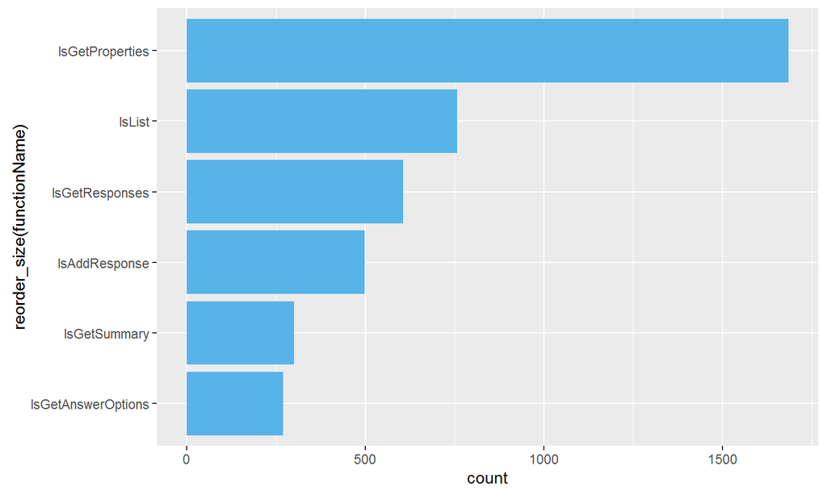

```r
    ggplot(data = dStats, aes(x = reorder_size(functionName))) +
        geom_bar(fill = "#56B4E9") + coord_flip()
```

## Data Products (LimeSurvey + R + LimeRick + Shiny)

https://kalimu.shinyapps.io/LimeRick_packageStats/

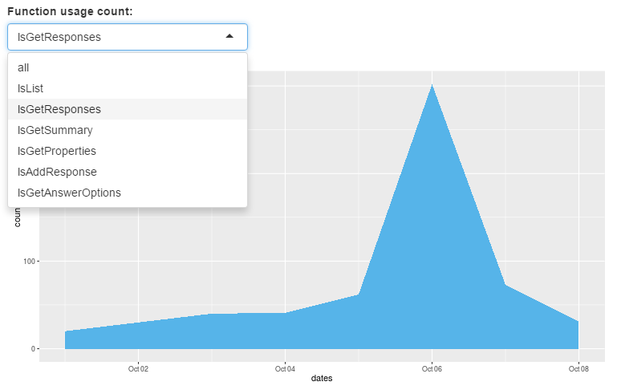

## Metadata analysis: traditional

- timings page-by-page
- lowest granularity possible: single question by page
- matrix with multi sub-questions still gives one timing

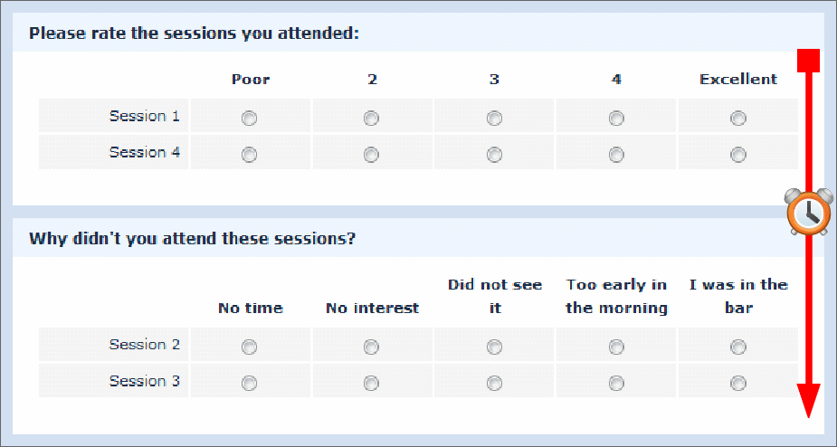

## Metadata analysis: low-granular

- timings between each respondent-survey interaction
- lowest granularity possible: keystroke or mouse click
- also logged when respondents change their answers

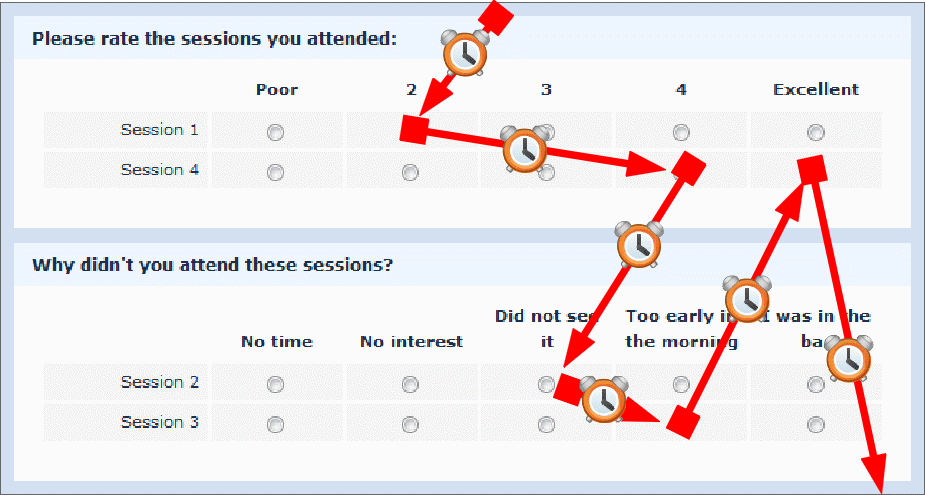

## Metadata analysis: summary

- with prototype of scripts that integrates with LimeSurvey (by Jarosław Szkoła)
- we can perform very detail meta-analysis of on-line survey by
  - merging existing and missing answers (non-response)  
    with detiled timings
  - reproducing each respondent interaction with a survey on very low level
  - aggregating low-level data to build Key Performance Indicators for on-line surveys
- in the future:
  - benchmarks for surveys and questions in pilot studies

## Call for collaboration

### Still much work to do:

- developing & testing new functionalities
- integrating the tool for metadata analysis
- submitting the package to CRAN
- publishing an academic paper
  - possible with real world case studies
- developing data products  
  for non-profit and commercial partners

The LimeRick GitHub repository is now open!  
github.com/kalimu/LimeRick

## Thank you!

Acknowledgements:

- Carsten Schmitz, LimeSurvey.org, Germany
- Andrew Heiss, [limer](https://github.com/andrewheiss), Great Britain
- Jarosław Szkoła, UITM, Poland
- Michał Pietal, Ph.D., [lowbattery.pl](http://lowbattery.pl/), Poland
- R User Group in Rzeszów, Poland

**Kamil Wais**  
e-mail: kamil.wais@gmail.com  
homepage: www.wais.kamil.rzeszow.pl

[figure not shown]

[figure not shown]